# **Laboratorio 4**

Integrantes del grupo

- Emmanuel Blanco - 202312743
- Juan David Guzmán - 202320890

### Importación de librerías

```python
import os
os.environ["LOKY_MAX_CPU_COUNT"] = "4"

import numpy as np
import matplotlib.pyplot as plt
import matplotlib.cm as cm
import seaborn as sns
import pandas as pd
import time
import math

from sklearn.metrics import silhouette_score, silhouette_samples, calinski_harabasz_score, davies_bouldin_score
from sklearn.cluster import KMeans, DBSCAN, AgglomerativeClustering
from sklearn.preprocessing import RobustScaler, MinMaxScaler, StandardScaler
from sklearn.pipeline import Pipeline
from sklearn.compose import ColumnTransformer
from sklearn.impute import SimpleImputer
from sklearn.preprocessing import OneHotEncoder, RobustScaler, StandardScaler
from sklearn.model_selection import ParameterGrid
from sklearn.tree import DecisionTreeClassifier, plot_tree
```

## **Carga de datos**

```python
datos = pd.read_csv("Datos_VuelaAlpes.csv",sep=",")

print("Dimensiones de los datos")
print("Filas: ",datos.shape[0])
print("Columnas: ",datos.shape[1])
```

```
Dimensiones de los datos
Filas:  10000
Columnas:  23
```

## **Exploración de datos**

```python
# Desplegamos el diccionario para entender que tipo de variables tenemos
diccionario = pd.read_excel("Diccionario VuelaAlpes.xlsx")
diccionario
```

|  | Variable | Tipo | Descripción |
| --- | --- | --- | --- |
| 0 | id | Entero | Identificador único del pasajero |
| 1 | Gender | Texto | Género del pasajero (Male / Female) |
| 2 | Customer Type | Texto | Tipo de cliente (Loyal Customer / disloyal Cus... |
| 3 | Age | Entero | Edad del pasajero |
| 4 | Type of Travel | Texto | Tipo de viaje (Business / Personal) |
| 5 | Class | Texto | Clase del vuelo (Eco, Eco Plus, Business) |
| 6 | Flight Distance | Entero | Distancia del vuelo |
| 7 | Inflight wifi service | Entero | Calificación del wifi (0–5) |
| 8 | Departure/Arrival time convenient | Entero | Conveniencia del horario (0–5) |
| 9 | Ease of Online booking | Entero | Facilidad de reserva online (0–5) |
| 10 | Gate location | Entero | Ubicación de la puerta (0–5) |
| 11 | Food and drink | Entero | Calidad de comida y bebida (0–5) |
| 12 | Online boarding | Entero | Experiencia de abordaje online (0–5) |
| 13 | Seat comfort | Entero | Comodidad del asiento (0–5) |
| 14 | Inflight entertainment | Entero | Entretenimiento a bordo (0–5) |
| 15 | On-board service | Entero | Servicio en cabina (0–5) |
| 16 | Leg room service | Entero | Espacio para piernas (0–5) |
| 17 | Baggage handling | Entero | Manejo de equipaje (0–5) |
| 18 | Checkin service | Entero | Servicio de check-in (0–5) |
| 19 | Inflight service | Entero | Servicio a bordo (0–5) |
| 20 | Cleanliness | Entero | Limpieza del avión (0–5) |
| 21 | Departure Delay in Minutes | Entero | Minutos de retraso en salida |
| 22 | Arrival Delay in Minutes | Float | Minutos de retraso en llegada (puede tener dec... |

A primera vista podemos ver que la mayoría de las variables son numéricas y ordinales , muchas de las variables representan una calificación de 0 a 5 en relación a un servicio.

```python
datos.describe()
```

|  | id | Age | Flight Distance | Inflight wifi service | Departure/Arrival time convenient | Ease of Online booking | Gate location | Food and drink | Online boarding | Seat comfort | Inflight entertainment | On-board service | Leg room service | Baggage handling | Checkin service | Inflight service | Cleanliness | Departure Delay in Minutes | Arrival Delay in Minutes |
| --- | --- | --- | --- | --- | --- | --- | --- | --- | --- | --- | --- | --- | --- | --- | --- | --- | --- | --- | --- |
| count | 10000.000000 | 10000.000000 | 10000.000000 | 10000.000000 | 10000.000000 | 10000.000000 | 10000.000000 | 10000.000000 | 10000.000000 | 10000.000000 | 10000.000000 | 10000.000000 | 10000.00000 | 10000.000000 | 10000.000000 | 10000.000000 | 10000.000000 | 10000.00000 | 9975.000000 |
| mean | 64983.058500 | 39.404300 | 1196.044800 | 2.734700 | 3.074000 | 2.762600 | 3.002800 | 3.215200 | 3.234500 | 3.431300 | 3.361900 | 3.391000 | 3.34440 | 3.635800 | 3.291700 | 3.643700 | 3.281200 | 14.86020 | 15.215439 |
| std | 37610.205164 | 15.072364 | 1000.590808 | 1.328718 | 1.520511 | 1.394287 | 1.283182 | 1.324486 | 1.350293 | 1.314935 | 1.329099 | 1.287123 | 1.31809 | 1.184271 | 1.263951 | 1.183085 | 1.311068 | 36.78467 | 37.370561 |
| min | 1.000000 | 7.000000 | 31.000000 | 0.000000 | 0.000000 | 0.000000 | 1.000000 | 0.000000 | 0.000000 | 1.000000 | 1.000000 | 1.000000 | 0.00000 | 1.000000 | 1.000000 | 1.000000 | 1.000000 | 0.00000 | 0.000000 |
| 25% | 32452.000000 | 27.000000 | 416.000000 | 2.000000 | 2.000000 | 2.000000 | 2.000000 | 2.000000 | 2.000000 | 2.000000 | 2.000000 | 2.000000 | 2.00000 | 3.000000 | 2.000000 | 3.000000 | 2.000000 | 0.00000 | 0.000000 |
| 50% | 64815.500000 | 40.000000 | 846.000000 | 3.000000 | 3.000000 | 3.000000 | 3.000000 | 3.000000 | 3.000000 | 4.000000 | 4.000000 | 4.000000 | 4.00000 | 4.000000 | 3.000000 | 4.000000 | 3.000000 | 0.00000 | 0.000000 |
| 75% | 97470.000000 | 51.000000 | 1744.000000 | 4.000000 | 4.000000 | 4.000000 | 4.000000 | 4.000000 | 4.000000 | 4.000000 | 4.000000 | 4.000000 | 4.00000 | 5.000000 | 4.000000 | 5.000000 | 4.000000 | 13.00000 | 13.000000 |
| max | 129879.000000 | 80.000000 | 4963.000000 | 5.000000 | 5.000000 | 5.000000 | 5.000000 | 5.000000 | 5.000000 | 5.000000 | 5.000000 | 5.000000 | 5.00000 | 5.000000 | 5.000000 | 5.000000 | 5.000000 | 930.00000 | 952.000000 |

```python
# Revisamos los datos nulos

porcentajes_NaN = (datos.isnull().sum()/(datos.shape[0]*100)).sort_values(ascending=False)
info_faltante = pd.DataFrame({
    'Columna':porcentajes_NaN.index,
    'Total de datos faltantes':datos.isnull().sum()[porcentajes_NaN.index].values,
    '%':porcentajes_NaN.values
})
info_faltante[info_faltante['Total de datos faltantes']>0]
```

|  | Columna | Total de datos faltantes | % |
| --- | --- | --- | --- |
| 0 | Arrival Delay in Minutes | 25 | 0.000025 |

Podemos ver que la variables Arrival Delay in minutes tiene filas vacías por lo que debemos completar esta columna

```python
print(f"Registros duplicados: {datos.duplicated().sum()}")
```

```
Registros duplicados: 0
```

Revisaremos el formato de las entradas en Gender, Customer Type, Type of travel y Class

```python
datos["Gender"].value_counts()
```

```
Gender
Female    5140
Male      4860
Name: count, dtype: int64
```

```python
datos["Customer Type"].value_counts()
```

```
Customer Type
Loyal Customer       8155
disloyal Customer    1845
Name: count, dtype: int64
```

```python
datos["Type of Travel"].value_counts()
```

```
Type of Travel
Business travel    6934
Personal Travel    3066
Name: count, dtype: int64
```

```python
datos["Class"].value_counts()
```

```
Class
Business    4856
Eco         4442
Eco Plus     702
Name: count, dtype: int64
```

Revisamos la distribución de los datos de acuerdo a las variables

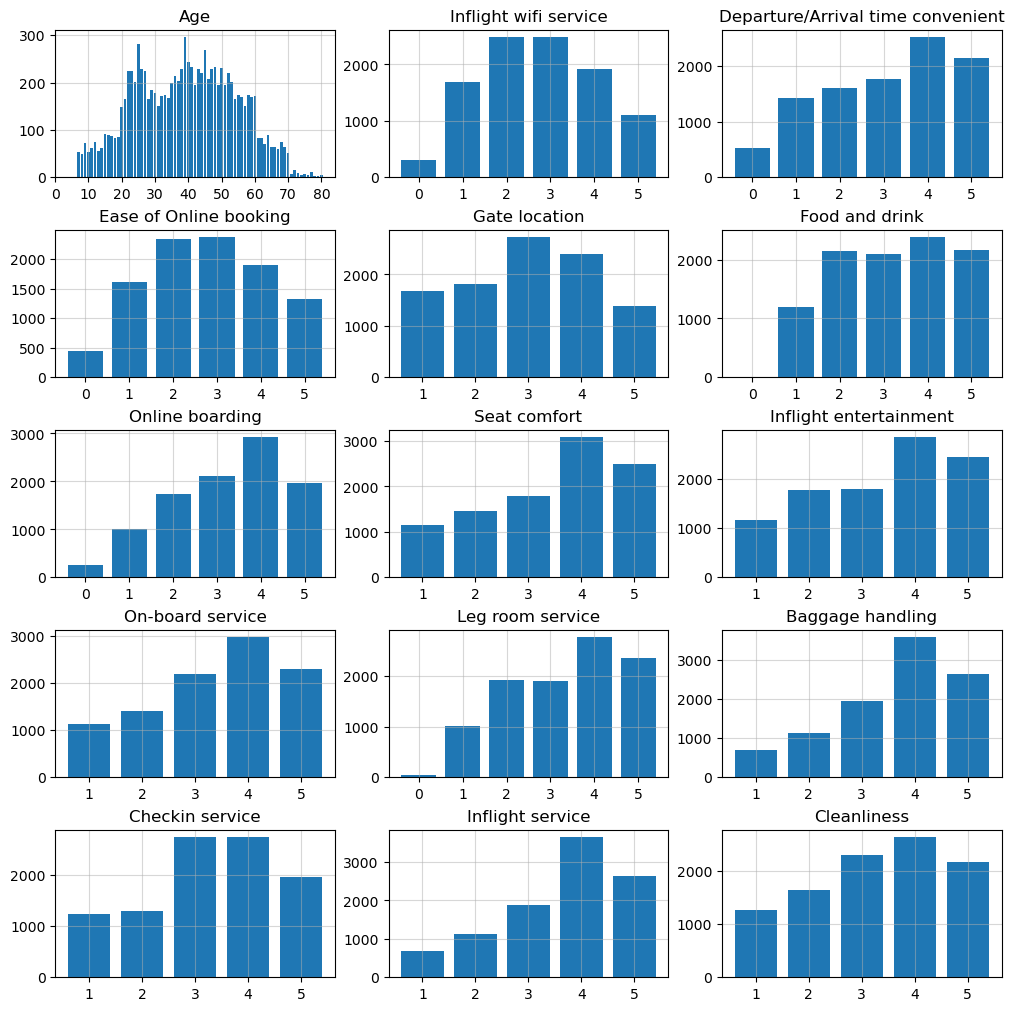

```python
# Hacemos una lista con las variables numéricas continuas
vars_hist = ["Flight Distance", "Departure Delay in Minutes"]
# Estas columnas se omiten para las siguientes operaciones
omitir = ["id","Flight Distance", "Departure Delay in Minutes","Arrival Delay in Minutes"]

vars_bar_plot = [
    col for col in datos.select_dtypes(include=[np.number]).columns
    if col not in omitir
]

# Vamos a hacer graficos de barras para ver como se distribuyen las variables en vars_bar_plot
fig, ax  = plt.subplots(5,3, layout="constrained",figsize=(10,10))

fila = 0
col = 0

for i in range(len(vars_bar_plot)):

    var = vars_bar_plot[i]
    counts = datos[var].value_counts()
    ax[fila][col].bar(counts.index,counts.values)
    ax[fila][col].grid(alpha=0.5)
    if var != "Age":
        ax[fila][col].set(title=var, xticks=counts.index)

    else:
        ax[fila][col].set(title=var, xticks= np.arange(0,81,10))

    if i == 2:
        fila = 1
        col = 0

    elif i == 5:
        fila = 2
        col = 0

    elif i == 8:
        fila = 3
        col = 0

    elif i == 11:
        fila = 4
        col = 0

    else:
        col+=1

plt.show()
```

[output not shown]

[output cut: 252 more lines]

[output not shown]

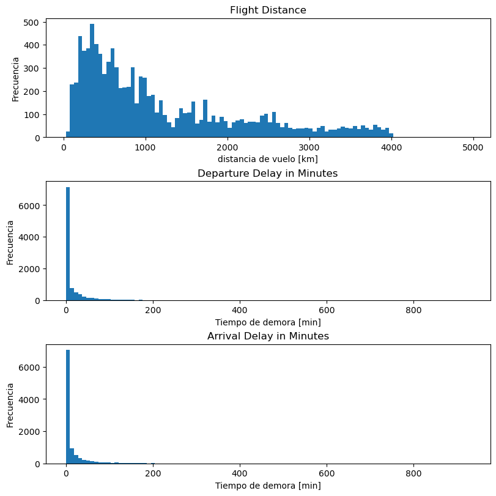

```python
# Hacemos una copia de la columna Arrival Delay in Minutes para poder graficar la distribución de sus datos (eliminando las columnas con NaN)
arrival_delay = datos["Arrival Delay in Minutes"]

# Eliminamos los datos nulos
arrival_delay.dropna(inplace=True)

#Graficamos los histogramas de las variables continuas
fig, ax  = plt.subplots(3,1, layout="constrained",figsize=(8,8))

# En este diccionario guardaremos la division de los datos en intervalos para poder desplegar la porción del total que representa cada bin
particion_bins = {}

# Para estas variables graficamos histogramas ya que son continuas
for i in range(len(vars_hist)):
    var = vars_hist[i]
    counts, bin_edges = np.histogram(datos[var], bins=100)
    ax[i].stairs(counts, bin_edges, fill=True)
    particion_bins[var] = (counts, bin_edges)
    if i == 0:
        ax[i].set(title=var, xlabel= "distancia de vuelo [km]", ylabel="Frecuencia")
    else:
        ax[i].set(title=var, xlabel="Tiempo de demora [min]", ylabel="Frecuencia")

counts, bin_egdes = np.histogram(arrival_delay,bins=100)
ax[2].stairs(counts, bin_edges, fill=True)
ax[2].set(title="Arrival Delay in Minutes", xlabel= "Tiempo de demora [min]", ylabel="Frecuencia")
particion_bins["Arrival Delay in Minutes"] = (counts, bin_edges)

# Calculamos la cantidad de datos en cada bin del histograma para ver qué procentaje del total representa cada bin
for key in particion_bins:
    print(f"Distribución {key}")
    counts, bin_edges = particion_bins[key]

    if key == "Arrival Delay in Minutes":
        for i in range(len(counts)):
            if i == 0:
                print(f"Intevalo de 0 a {round(bin_edges[i],3)}: {round((counts[i]/arrival_delay.shape[0])*100,3)}%")

            else:
                print(f"Intervalos de {round(bin_edges[i-1]+0.1,3)} a {round(bin_edges[i],3)}: {round((counts[i]/arrival_delay.shape[0])*100,3)}%")

    else:
        for i in range(len(counts)):
            if i == 0:
                print(f"Intevalo de 0 a {round(bin_edges[i],3)}: {round((counts[i]/datos.shape[0])*100,3)}%")
            else:
                print(f"Intervalos de {round(bin_edges[i-1]+0.1,3)} a {round(bin_edges[i],3)}: {round((counts[i]/datos.shape[0])*100,3)}%")

    print("\n")

plt.show()
```

Haciendo una inspección de los gráficos podemos identificar los siguiente:

- Las variables ordinales que califican distintos aspectos del servicio no parecen presentar muchos problemas, en algunas variables las calificaciones de 0 son muy pocas en comparación a las demás calificaciones. Pero en general no se presentarían muchos problemas con estas variables
- En la variable edad la mayoría de los datos se concentra entre los 20 y 60 años. Los datos entre 70 y 80 años parecen ser escasos, por lo que debemos tratar esto con cuidado
- Las demoras en Arrival y Departure son en su mayoría de valor 0, lo cual genera un gran desbalance en los datos de estas variables. Es muy posible que los datos con demoras de 100 min en adelante sean tomados como outliers. Por lo tanto hay que revisar como manejar estas variables a la hora de preparar los datos para usar modelos como K-means que son sensibles a los outliers
- En particular hay que tener cuidado con la imputación de valores faltantes en Arrival Delay por lo mencionado anteriormente respecto a los outliers, quizá sea mejor imputar la mediana o moda en lugar de imputar la media

## **Limpieza y Preparación de datos**

```python
# 1. Eliminamos la columna 'id' que no nos aporta valor predictivo
if 'id' in datos.columns:
    datos_modelo = datos.drop('id', axis=1)
else:
    datos_modelo = datos.copy()

# 2. Defininimos ahor las columnas según su tipo
numeric_cols = ["Age","Flight Distance","Departure Delay in Minutes","Arrival Delay in Minutes"]
ordinal_cols= [col for col in datos_modelo.select_dtypes(include=[np.number]).columns if col not in numeric_cols]
categorical_cols = ["Gender", "Customer Type", "Type of Travel", "Class"]

# 3. Construimos el ColumnTransformer

# Caso para numericas continuas
    # Imputacion de mediana (para completar Arrival Delay) y RobustScaler para tratar con los outliers
numeric_outliers_transformer = Pipeline(steps=[
    ('imputer', SimpleImputer(strategy='median')),
    ('scaler', RobustScaler()),
])

# Caso numéricas ordinales
   # Escalamiento con MinMaxScaler
ordinal_transformer = Pipeline(steps=[
    ('scaler',MinMaxScaler())
])

# Para categoricas, se ejerce imputacion de moda y OneHotEncoder
categorical_transformer = Pipeline(steps=[
    ('onehot', OneHotEncoder(sparse_output=False)),
])

preprocessor = ColumnTransformer(
    transformers=[
        ('num', numeric_outliers_transformer, numeric_cols),
        ('ord',ordinal_transformer, ordinal_cols),
        ('cat', categorical_transformer, categorical_cols)
    ])

# Preprocesamiento a los datos
X_prep = preprocessor.fit_transform(datos_modelo)
print(X_prep.shape[0])

# Muestra aleatoria para agrupamiento dado el costo computacional de DBSCAN o Agglomerative
np.random.seed(42)

sample_size = min(15000, X_prep.shape[0])
sample_indices = np.random.choice(X_prep.shape[0], size=sample_size, replace=False)
X_sample = X_prep[sample_indices]

print(f"Dimensiones completos: {X_prep.shape}")
print(f"Dimensiones muestra: {X_sample.shape}")
```

```
10000
Dimensiones completos: (10000, 27)
Dimensiones muestra: (10000, 27)
```

## **Modelamiento**

### 1. K-MEANS

Primero evaluamos qué parámetros podrían ser los mejores para k-means. Para tomar esta decisión nos apoyaremos en la métricas de silueta, inercia y los scores de calinski y davies (estos dos último fueron sugeridos por la IA)

```python
def evaluar_kmeans(X, k_min=2, k_max=10):
    ks = list(range(k_min, k_max + 1))

    inertias = []
    silhouettes = []
    calinski_scores = []
    davies_scores = []

    for k in ks:
        model = KMeans(
            n_clusters=k,
            random_state=42,
            n_init=20
        )

        labels = model.fit_predict(X)

        inertias.append(model.inertia_)
        silhouettes.append(silhouette_score(X, labels))
        calinski_scores.append(calinski_harabasz_score(X, labels))
        davies_scores.append(davies_bouldin_score(X, labels))

    # gráficos
    plt.figure(figsize=(12,8))

    plt.subplot(2,2,1)
    plt.plot(ks, inertias, marker='o')
    plt.title("Elbow (Inercia)")
    plt.xlabel("k")

    plt.subplot(2,2,2)
    plt.plot(ks, silhouettes, marker='o')
    plt.title("Silhouette")
    plt.xlabel("k")

    plt.subplot(2,2,3)
    plt.plot(ks, calinski_scores, marker='o')
    plt.title("Calinski-Harabasz")
    plt.xlabel("k")

    plt.subplot(2,2,4)
    plt.plot(ks, davies_scores, marker='o')
    plt.title("Davies-Bouldin")
    plt.xlabel("k")

    plt.tight_layout()
    plt.show()
```

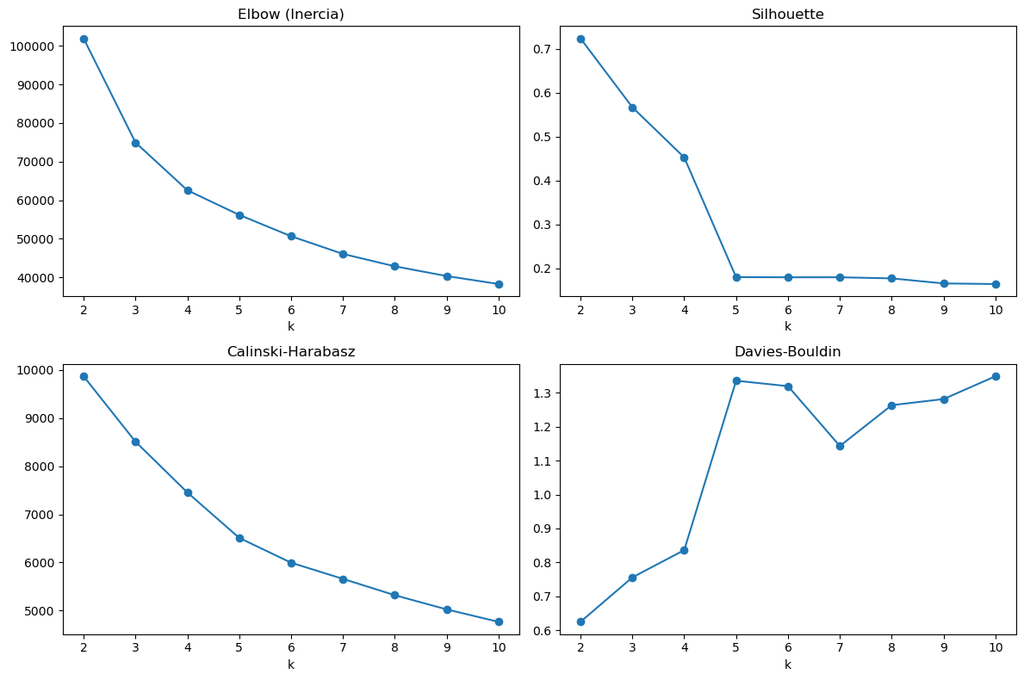

```python
evaluar_kmeans(X_sample)
```

Podemos ver que las gráficas nos muestran que los valores K = 2, 3 y 4 podrían ser adecuados para agrupar nuestros datos (Estos son los valores con silueta, inercia y Calinski más altos, y de Davies más bajos)

```
Entrenando KMeans...

KMeans (k=2) - Silueta: 0.7233
```

|  | Cluster | Número de clientes |
| --- | --- | --- |
| 0 | 0 | 9416 |
| 1 | 1 | 584 |

```
KMeans (k=3) - Silueta: 0.5672
```

|  | Cluster | Número de clientes |
| --- | --- | --- |
| 0 | 0 | 8852 |
| 1 | 1 | 173 |
| 2 | 2 | 975 |

```
KMeans (k=4) - Silueta: 0.1708
```

|  | Cluster | Número de clientes |
| --- | --- | --- |
| 0 | 0 | 4255 |
| 1 | 1 | 171 |
| 2 | 2 | 949 |
| 3 | 3 | 4625 |

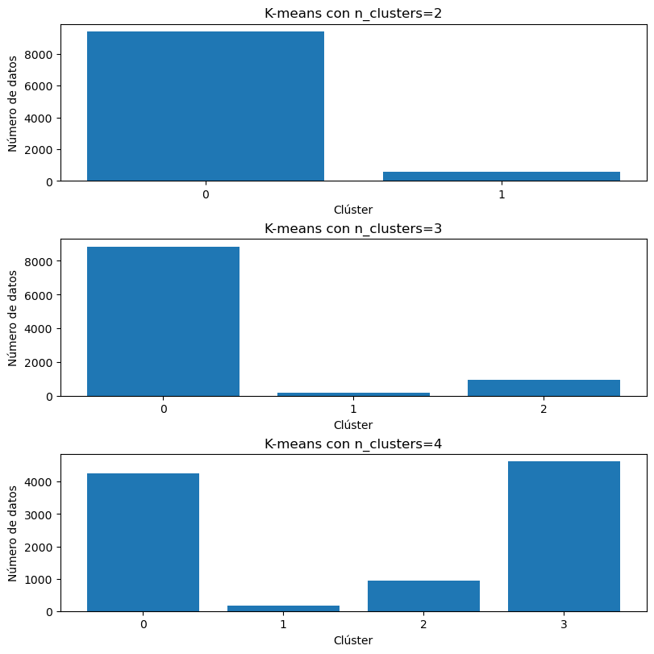

```python
print("Entrenando KMeans...")
# Iteraremos probando distinto número de clusters
kmeans_params = {'n_clusters': [2, 3, 4]}
best_kmeans_score = -1
best_kmeans_model = None

fig, ax = plt.subplots(3,1,figsize=(8,8),layout="constrained")

for i in range(len(kmeans_params['n_clusters'])):
    k = kmeans_params['n_clusters'][i]
    kmeans = KMeans(n_clusters=k, random_state=42, n_init="auto")
    labels = kmeans.fit_predict(X_sample)
    indexes, values = np.unique(labels, return_counts=True)
    score = silhouette_score(X_sample, labels)
    print(f"\nKMeans (k={k}) - Silueta: {score:.4f}")
    ax[i].bar(indexes,values)
    ax[i].set(xlabel="Clúster",ylabel="Número de datos",xticks=indexes, title=f"K-means con n_clusters={k}")

    tabla = pd.DataFrame({
    'Cluster': indexes,
    'Número de clientes': values
    })
    tabla = tabla.sort_values(by='Cluster').reset_index(drop=True)
    display(tabla)

plt.show()
```

Podemos ver que si bien con dos clusters se está haciendo una agrupación con alto score de silueta, casi todos los datos van al clúster 0. Por otro lado usar K=4 nos da el peor resultado en silueta pero hace una agrupación un poco más balanceada entre los clústers 0 y 3, pero si tiene desbalances con los clústers 1 y 2.

Sin embargo, revisando las variables ordinales que representan calificaciones que graficamos en la exploración de datos podemos ver que las calificaciones de 0, 1 y 2 no son tantas en comparación a las calificaciones de 3, 4 y 5. Además, recordemos que para las variables de demora en Llegada o Salida la mayoría de los datos estaba con valor cero o cercano a cero. Estos hallazgos podrían explicar porque el resultado con mejor silueta lleva la mayoría de datos al clúster 0 y los demás al clúster 1.

```python
# Ahora guardaremos el mejor modelo para analizarlo más a detalle en la sección de análisis
resultados_modelos = []

# Volvemos a generar el objeto del modelo
start_time = time.time()
mejor_kmeans = KMeans(n_clusters=2,random_state=42, n_init="auto")
labels = mejor_kmeans.fit_predict(X_sample)
tiempo = time.time() - start_time
score = silhouette_score(X_sample, labels)

resultados_modelos.append({
    'Modelo':'K-Means',
    'Mejores hiperparámetros': 'n_clusters = 2',
    'Silhouette Score': score,
    'Objeto Modelo':mejor_kmeans,
    'Tiempo (s)':tiempo,
    'labels':labels
})
```

### 2. DBSCAN

```
Entrenando DBSCAN...

DBSCAN (eps=1.0, min_samples=5) - Silueta: 0.0738 - Clusters reales: 34
```

|  | Cluster | Número de clientes |
| --- | --- | --- |
| 0 | -1 | 4026 |
| 1 | 0 | 1323 |
| 2 | 1 | 780 |
| 3 | 2 | 307 |
| 4 | 3 | 1324 |
| 5 | 4 | 240 |
| 6 | 5 | 748 |
| 7 | 6 | 270 |
| 8 | 7 | 3 |
| 9 | 8 | 205 |
| 10 | 9 | 74 |
| 11 | 10 | 12 |
| 12 | 11 | 3 |
| 13 | 12 | 246 |
| 14 | 13 | 4 |
| 15 | 14 | 261 |
| 16 | 15 | 11 |
| 17 | 16 | 42 |
| 18 | 17 | 33 |
| 19 | 18 | 2 |
| 20 | 19 | 5 |
| 21 | 20 | 8 |
| 22 | 21 | 4 |
| 23 | 22 | 14 |
| 24 | 23 | 6 |
| 25 | 24 | 5 |
| 26 | 25 | 5 |
| 27 | 26 | 5 |
| 28 | 27 | 5 |
| 29 | 28 | 5 |
| 30 | 29 | 4 |
| 31 | 30 | 5 |
| 32 | 31 | 5 |
| 33 | 32 | 5 |
| 34 | 33 | 5 |

```
DBSCAN (eps=1.0, min_samples=10) - Silueta: 0.1914 - Clusters reales: 11
```

|  | Cluster | Número de clientes |
| --- | --- | --- |
| 0 | -1 | 4744 |
| 1 | 0 | 1234 |
| 2 | 1 | 706 |
| 3 | 2 | 270 |
| 4 | 3 | 1225 |
| 5 | 4 | 226 |
| 6 | 5 | 244 |
| 7 | 6 | 683 |
| 8 | 7 | 39 |
| 9 | 8 | 232 |
| 10 | 9 | 213 |
| 11 | 10 | 184 |

```
DBSCAN (eps=1.0, min_samples=15) - Silueta: 0.1926 - Clusters reales: 11
```

|  | Cluster | Número de clientes |
| --- | --- | --- |
| 0 | -1 | 5214 |
| 1 | 0 | 651 |
| 2 | 1 | 1152 |
| 3 | 2 | 1156 |
| 4 | 3 | 207 |
| 5 | 4 | 203 |
| 6 | 5 | 639 |
| 7 | 6 | 201 |
| 8 | 7 | 165 |
| 9 | 8 | 153 |
| 10 | 9 | 244 |
| 11 | 10 | 15 |

```
DBSCAN (eps=1.2, min_samples=5) - Silueta: 0.1124 - Clusters reales: 32
```

|  | Cluster | Número de clientes |
| --- | --- | --- |
| 0 | -1 | 2311 |
| 1 | 0 | 1617 |
| 2 | 1 | 1011 |
| 3 | 2 | 1602 |
| 4 | 3 | 428 |
| 5 | 4 | 281 |
| 6 | 5 | 972 |
| 7 | 6 | 325 |
| 8 | 7 | 291 |
| 9 | 8 | 109 |
| 10 | 9 | 325 |
| 11 | 10 | 298 |
| 12 | 11 | 85 |
| 13 | 12 | 67 |
| 14 | 13 | 41 |
| 15 | 14 | 28 |
| 16 | 15 | 84 |
| 17 | 16 | 15 |
| 18 | 17 | 5 |
| 19 | 18 | 15 |
| 20 | 19 | 5 |
| 21 | 20 | 19 |
| 22 | 21 | 5 |
| 23 | 22 | 7 |
| 24 | 23 | 7 |
| 25 | 24 | 7 |
| 26 | 25 | 7 |
| 27 | 26 | 3 |
| 28 | 27 | 9 |
| 29 | 28 | 6 |
| 30 | 29 | 5 |
| 31 | 30 | 5 |
| 32 | 31 | 5 |

```
DBSCAN (eps=1.2, min_samples=10) - Silueta: 0.1362 - Clusters reales: 19
```

|  | Cluster | Número de clientes |
| --- | --- | --- |
| 0 | -1 | 2846 |
| 1 | 0 | 1542 |
| 2 | 1 | 976 |
| 3 | 2 | 411 |
| 4 | 3 | 1536 |
| 5 | 4 | 279 |
| 6 | 5 | 908 |
| 7 | 6 | 309 |
| 8 | 7 | 278 |
| 9 | 8 | 99 |
| 10 | 9 | 292 |
| 11 | 10 | 315 |
| 12 | 11 | 10 |
| 13 | 12 | 18 |
| 14 | 13 | 75 |
| 15 | 14 | 51 |
| 16 | 15 | 9 |
| 17 | 16 | 10 |
| 18 | 17 | 11 |
| 19 | 18 | 25 |

```
DBSCAN (eps=1.2, min_samples=15) - Silueta: 0.1618 - Clusters reales: 14
```

|  | Cluster | Número de clientes |
| --- | --- | --- |
| 0 | -1 | 3168 |
| 1 | 0 | 1502 |
| 2 | 1 | 921 |
| 3 | 2 | 387 |
| 4 | 3 | 1504 |
| 5 | 4 | 271 |
| 6 | 5 | 890 |
| 7 | 6 | 303 |
| 8 | 7 | 265 |
| 9 | 8 | 95 |
| 10 | 9 | 288 |
| 11 | 10 | 304 |
| 12 | 11 | 53 |
| 13 | 12 | 33 |
| 14 | 13 | 16 |

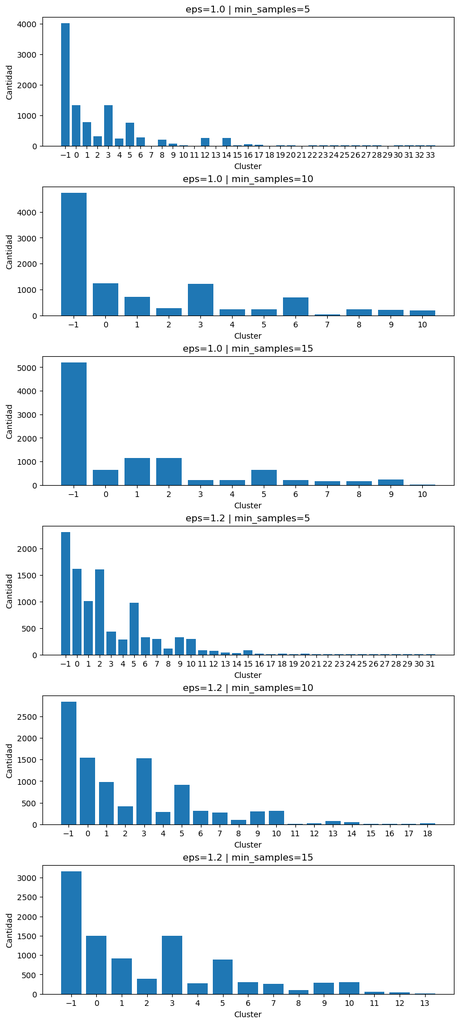

```python
print("\nEntrenando DBSCAN...")

dbscan_params = {
    'eps': [1.0, 1.2],
    'min_samples': [5, 10, 15]
}

param_grid = list(ParameterGrid(dbscan_params))

fig, ax = plt.subplots(len(param_grid), 1, figsize=(8, 3*len(param_grid)), layout="constrained")

if len(param_grid) == 1:
    ax = [ax]

for i, params in enumerate(param_grid):

    dbscan = DBSCAN(**params)
    labels = dbscan.fit_predict(X_sample)

    # clusters reales (sin ruido)
    real_clusters = set(labels) - {-1}

    # calcular silueta solo si hay al menos 2 clusters reales
    if len(real_clusters) >= 2:
        mask = labels != -1
        score = silhouette_score(X_sample[mask], labels[mask])
    else:
        score = -1

    indexes, values = np.unique(labels, return_counts=True)

    print(
        f"\nDBSCAN (eps={params['eps']}, min_samples={params['min_samples']}) "
        f"- Silueta: {score:.4f} "
        f"- Clusters reales: {len(real_clusters)}"
    )

    ax[i].bar(indexes, values)
    ax[i].set_title(f"eps={params['eps']} | min_samples={params['min_samples']}")
    ax[i].set(xlabel="Cluster", ylabel="Cantidad", xticks=indexes)

    tabla = pd.DataFrame({
    'Cluster': indexes,
    'Número de clientes': values
    })
    tabla = tabla.sort_values(by='Cluster').reset_index(drop=True)
    display(tabla)

plt.show()
```

Se consultó a la IA sobre cómo se podría mejorar el desempeño de DBSCAN y se nos propuso usar PCA, el problema con PCA es que tranforma las variables en nuevas variables reduciendo la complejidad del dataset original pero lo hace sin mostrar explícitamente como hace las transformaciones, es decir es una herramienta de "caja negra". Dado que en este curso se nos piden modelos interpretables y en donde se pueda ver qué transformaciones se hacen y el por qué no haremos uso de PCA como nos sugirió la IA y simplemente seleccionaremos el mejor modelo de DBSCAN comúny corriente.

```python
# Guardamos el mejor modelo de DBSCAN
start_time = time.time()
mejor_DBSCAN = DBSCAN(eps=1.0,min_samples=15)
labels = mejor_DBSCAN.fit_predict(X_sample)
tiempo = time.time() - start_time
score = silhouette_score(X_sample, labels)

resultados_modelos.append({
    'Modelo':'DBSCAN',
    'Mejores hiperparámetros': 'eps = 1.0, min_samples = 15',
    'Silhouette Score': score,
    'Objeto Modelo':mejor_DBSCAN,
    'Tiempo (s)':tiempo,
    'labels':labels
})
```

### 3. AGGLOMERATIVE CLUSTERING

```
Entrenando Agglomerative Clustering...

Agglomerative (k=2) - Silueta: 0.7758
```

|  | Cluster | Número de clientes |
| --- | --- | --- |
| 0 | 0 | 9707 |
| 1 | 1 | 293 |

```
Agglomerative (k=3) - Silueta: 0.5149
```

|  | Cluster | Número de clientes |
| --- | --- | --- |
| 0 | 0 | 293 |
| 1 | 1 | 8766 |
| 2 | 2 | 941 |

```
Agglomerative (k=4) - Silueta: 0.5168
```

|  | Cluster | Número de clientes |
| --- | --- | --- |
| 0 | 0 | 8766 |
| 1 | 1 | 48 |
| 2 | 2 | 941 |
| 3 | 3 | 245 |

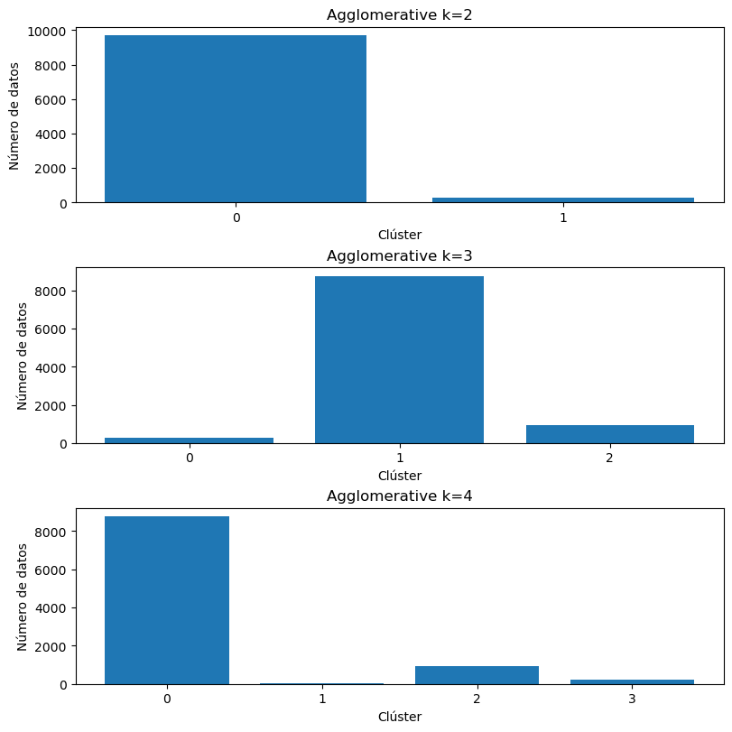

```python
print("\nEntrenando Agglomerative Clustering...")
start_time = time.time()

#Definimos los parámetros que probaremos
agg_params = {'n_clusters': [2, 3, 4]}

fig, ax = plt.subplots(3,1,figsize=(8,8),layout="constrained")

for i in range(len(agg_params['n_clusters'])):
    k = agg_params['n_clusters'][i]
    agg_model = AgglomerativeClustering(n_clusters=k)
    labels = agg_model.fit_predict(X_sample)
    indexes, values = np.unique(labels, return_counts=True)
    score = silhouette_score(X_sample, labels)
    print(f"\nAgglomerative (k={k}) - Silueta: {score:.4f}")
    ax[i].bar(indexes,values)
    ax[i].set(xlabel="Clúster",ylabel="Número de datos",xticks=indexes, title=f"Agglomerative k={k}")

    tabla = pd.DataFrame({
    'Cluster': indexes,
    'Número de clientes': values
    })
    tabla = tabla.sort_values(by='Cluster').reset_index(drop=True)
    display(tabla)

plt.show()
```

Con Agglomerative clustering vemos que en el caso con mejor silueta se tienen 2 clusters y la agrupación genera que la mayoría de datos vayan a el clúster 0 y los demás al clúster 1. Este resultado se podría justificar teniendo en cuenta lo ya mencionado para el mejor resultado de K-means (lo cual también aplica a este caso)

```python
# Guardamos el mejor modelo de Agglomerative
start_time = time.time()
mejor_agg = AgglomerativeClustering(n_clusters=2)
labels = mejor_agg.fit_predict(X_sample)
tiempo = time.time() - start_time
score = silhouette_score(X_sample, labels)

resultados_modelos.append({
    'Modelo':'Agglomerative Clustering',
    'Mejores hiperparámetros': 'n_clusters = 2',
    'Silhouette Score': score,
    'Objeto Modelo':mejor_agg,
    'Tiempo (s)':tiempo,
    'labels':labels
})
```

## **Análisis de resultados**

### **Evaluación cuantitativa**

```
Datos por clúster con modelo K-Means
```

|  | Cluster | Número de clientes |
| --- | --- | --- |
| 0 | 0 | 9416 |
| 1 | 1 | 584 |

```
Datos por clúster con modelo DBSCAN
```

|  | Cluster | Número de clientes |
| --- | --- | --- |
| 0 | -1 | 5214 |
| 1 | 0 | 651 |
| 2 | 1 | 1152 |
| 3 | 2 | 1156 |
| 4 | 3 | 207 |
| 5 | 4 | 203 |
| 6 | 5 | 639 |
| 7 | 6 | 201 |
| 8 | 7 | 165 |
| 9 | 8 | 153 |
| 10 | 9 | 244 |
| 11 | 10 | 15 |

```
Datos por clúster con modelo Agglomerative Clustering
```

|  | Cluster | Número de clientes |
| --- | --- | --- |
| 0 | 0 | 9707 |
| 1 | 1 | 293 |

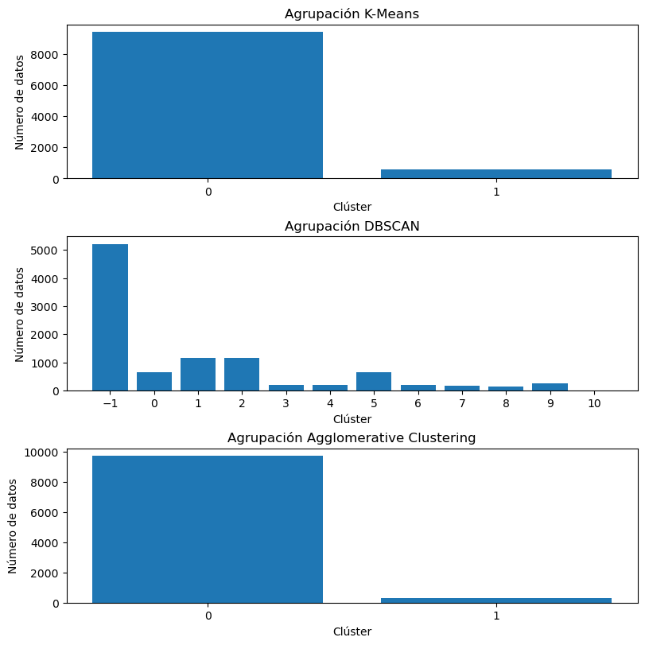

```python
fig, ax = plt.subplots(3,1,figsize=(8,8),layout="constrained")

for i in range(len(resultados_modelos)):
    labels = resultados_modelos[i]["labels"]
    indexes, values = np.unique(labels, return_counts=True)

    print(f"\nDatos por clúster con modelo {resultados_modelos[i]["Modelo"]}")

    tabla = pd.DataFrame({
    'Cluster': indexes,
    'Número de clientes': values
    })
    tabla = tabla.sort_values(by='Cluster').reset_index(drop=True)
    display(tabla)

    ax[i].bar(indexes,values)
    ax[i].set(xlabel="Clúster",ylabel="Número de datos",xticks=indexes, title=f"Agrupación {resultados_modelos[i]["Modelo"]}")


plt.show()
```

```python
def silhouette_analysis_results(X, resultados_modelos):
    """
    Genera gráficas de silueta usando la lista de resultados guardados.

    Parámetros:
    X : np.array
        Datos originales.
    resultados_modelos : list
        Lista de diccionarios con información del modelo.
        Deben incluir 'Modelo', 'Silhouette Score' y 'Objeto Modelo'.
    """

    for resultado in resultados_modelos:
        modelo_nombre = resultado['Modelo']
        silhouette_avg = resultado['Silhouette Score']
        modelo = resultado['Objeto Modelo']

        # Obtener etiquetas
        if hasattr(modelo, "labels_"):
            cluster_labels = modelo.labels_
        else:
            cluster_labels = modelo.predict(X)

        n_clusters = len(np.unique(cluster_labels))

        # Valores individuales
        sample_silhouette_values = silhouette_samples(X, cluster_labels)

        # Figura
        plt.figure(figsize=(18, 7))
        plt.xlim([-0.2, 1])
        plt.ylim([0, len(X) + (n_clusters + 1) * 10])

        y_lower = 10

        for i in range(n_clusters):
            ith_cluster_silhouette_values = sample_silhouette_values[cluster_labels == i]
            ith_cluster_silhouette_values.sort()

            size_cluster_i = ith_cluster_silhouette_values.shape[0]
            y_upper = y_lower + size_cluster_i

            color = cm.nipy_spectral(float(i) / n_clusters)

            plt.fill_betweenx(
                np.arange(y_lower, y_upper),
                0,
                ith_cluster_silhouette_values,
                facecolor=color,
                edgecolor=color,
                alpha=0.7
            )

            plt.text(-0.05, y_lower + 0.5 * size_cluster_i, str(i))
            y_lower = y_upper + 10

        plt.title(f"Método de la silueta - {modelo_nombre} (clusters = {n_clusters})")
        plt.xlabel("Coeficiente")
        plt.ylabel("Clúster")

        plt.axvline(x=silhouette_avg, color="red", linestyle="--")
        plt.yticks([])
        plt.xticks([-0.2, 0, 0.2, 0.4, 0.6, 0.8, 1])

        plt.show()
```

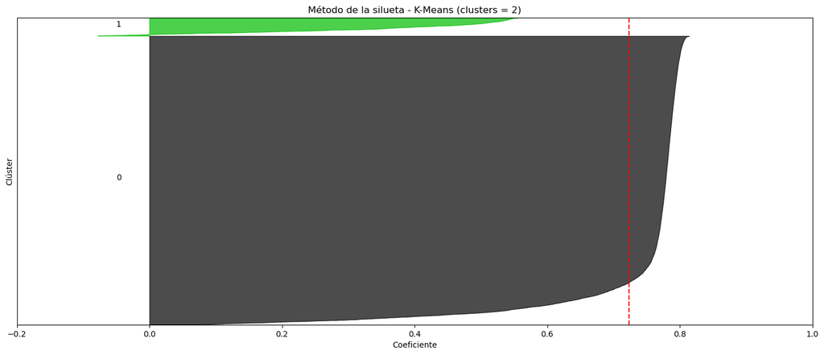

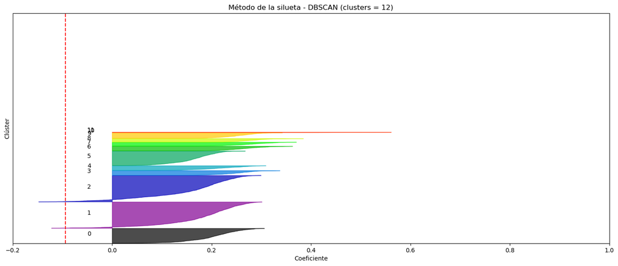

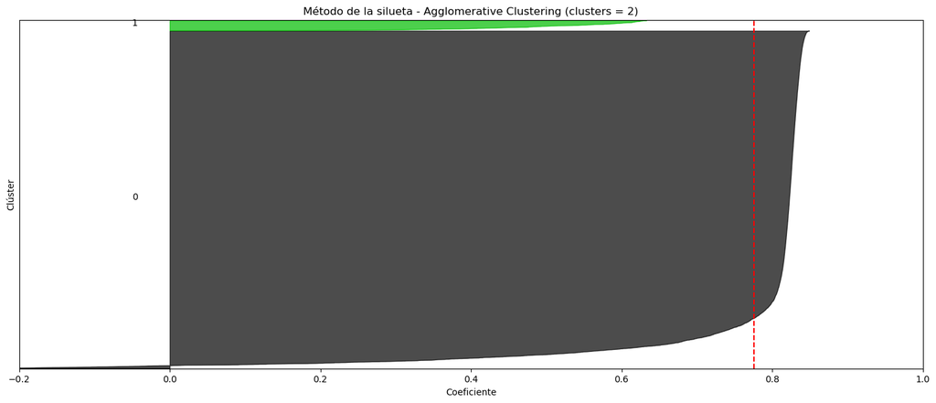

```python
silhouette_analysis_results(X_sample,resultados_modelos)
```

```python
# Ordenamos los modelos de acuerdo al que tuvo mejor score de silueta
df_resultados = pd.DataFrame(resultados_modelos)
df_resultados.sort_values(by='Silhouette Score', ascending=False, inplace=True)
df_resultados[["Modelo","Mejores hiperparámetros","Silhouette Score"]]
```

|  | Modelo | Mejores hiperparámetros | Silhouette Score |
| --- | --- | --- | --- |
| 2 | Agglomerative Clustering | n_clusters = 2 | 0.775794 |
| 0 | K-Means | n_clusters = 2 | 0.723262 |
| 1 | DBSCAN | eps = 1.0, min_samples = 15 | -0.093811 |

Teniendo en cuenta el resultado que tuvimos con la métrica de la silueta y lo que observamos respecto a la distribución de los datos podemos establecer que el mejor modelo de agrupación es el modelo de Agglomerative clustering que agrupa usando 2 clusters.

Si bien la agrupación en los clusters es un poco desproporcionada, vemos en las figuras de la silueta que las figuras de los clusters son las que mejor se aproximan al umbral en rojo

### **Evaluación cualitativa**

[output not shown]

[output cut: 35 more lines]

[output not shown]

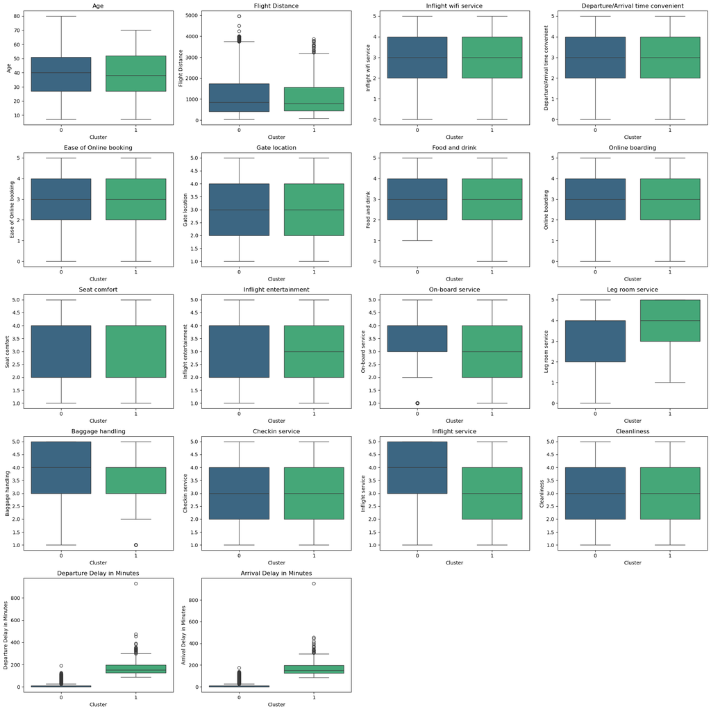

```
Entrenando Árbol de Decisión explicativo...
```

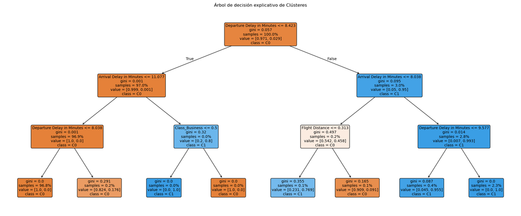

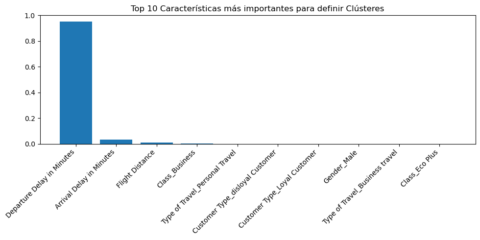

```python
# Agglomerative clustering fue el mejor modelo para interpretar (mejor silueta)
best_labels = resultados_modelos[2]["labels"]

# Agregamos las etiquetas a nuestra muestra original para interpretar
df_sample = datos_modelo.iloc[sample_indices].copy()
df_sample['Cluster'] = best_labels

# Boxplots
vars_to_plot = [
    col for col in datos.select_dtypes(include=[np.number]).columns
    if col != "id"
]

n_cols = 4
n_rows = math.ceil(len(vars_to_plot) / n_cols)

fig, axes = plt.subplots(n_rows, n_cols, figsize=(5*n_cols, 4*n_rows))
axes = axes.flatten()

for i, var in enumerate(vars_to_plot):
    if var in df_sample.columns:
        sns.boxplot(
            x='Cluster',
            y=var,
            data=df_sample,
            ax=axes[i],
            palette='viridis'
        )
        axes[i].set_title(f"{var}")

# eliminar ejes sobrantes
for j in range(i+1, len(axes)):
    fig.delaxes(axes[j])

plt.tight_layout()
plt.show()

# Árbol de decisión explicativo
print("Entrenando Árbol de Decisión explicativo...")
dt_explainer = DecisionTreeClassifier(max_depth=3, random_state=42)
dt_explainer.fit(X_sample, best_labels)

# Obtener nombres de las características preprocesadas
cat_encoder = preprocessor.named_transformers_['cat'].named_steps['onehot']
cat_features = cat_encoder.get_feature_names_out(categorical_cols)
feature_names = numeric_cols + ordinal_cols + list(cat_features)

plt.figure(figsize=(25, 10))
plot_tree(dt_explainer, feature_names=feature_names, class_names=[f"C{i}" for i in np.unique(best_labels)], filled=True, rounded=True, proportion=True, fontsize=10)
plt.title("Árbol de decisión explicativo de Clústeres")
plt.show()

# Importancia
importances = dt_explainer.feature_importances_
indices = np.argsort(importances)[::-1][:10]

plt.figure(figsize=(10, 5))
plt.title("Top 10 Características más importantes para definir Clústeres")
plt.bar(range(10), importances[indices], align="center")
plt.xticks(range(10), [feature_names[i] for i in indices], rotation=45, ha='right')
plt.tight_layout()
plt.show()
```

Podemos ver que en general las distribución de las variables es buena ya que para la mayoría de los boxplots no se encuentran muchos outliers y el grosor de las cajas no es demasiado. También la distribución es bastante simétrica con respecto a la mediana en varios casos.

### Respuestas a las preguntas de Análisis de Resultados

**2. ¿Qué criterios son importantes para la selección del algoritmo?**

- Escalabilidad computacional (para grandes volúmenes K-Means es mucho mejor).
- Forma esperada de los clústeres (K-Means para esféricos, DBSCAN para densidad que son arbitrarias).
- Interpretabilidad de cara al negocio pues K-Means arroja un $K$ claro y fácil de entender.
- Por ult. la resistencia al ruido.

**3. ¿Cómo medir la calidad del modelo construido? ¿Cómo saber que el modelo construido tiene una buena calidad?**

- Mediante metricas intrinsecas como el **Coeficiente de Silueta**, pues sabemos que es de buena calidad si el coeficiente es positivo y cercano a 1 (buena cohesión y separación).

**4. ¿Cómo varía la calidad de la solución obtenida si se aplican diferentes algoritmos?**

- Varia drasticamente debido al metodo matematico base, ya que K-Means intenta agrupar equitativamente mientras DBSCAN puede etiquetar la mayor parte como "ruido" si el `eps` no captura la densidad correcta, afectando fuertemente y claramente el coeficiente de Silueta.

**5. ¿Cómo interpretar el resultado de la ejecución de los algoritmos de agrupación seleccionados?**

- Utilizando la tecnica de reglas generadas por el Árbol de Decisión y los boxplots. Podemos observar que ciertas las variables de demora en salida y demora en llegada juegan un papel importante en la agrupación de los clientes, esto le permite a VuelaAlpes identificar un perfil de cliente para tomar decisiones de negocio y entrenar tripulación.

## **Enlace al video explicativo de los resultados**

[Enlace video](https://www.youtube.com/watch?v=yWXm62zmyfE)

## Uso de IA

El uso de IA en este laboratorio no fue mucho, en general se le pidió a la IA ChatGPT modificar algunos de los métodos de las prácticas de la materia para adaptarlos a nuestro laboratorio. También hubo un par de recomendaciones de la IA, una que se incluyó y otra que no, la que se incluyó tiene que ver con los scores para hallar el mejor parámetro de K-means, donde se incluyeron dos indicadores más aparte de los vistos en clase; y la no incluida tiene que ver con una mejora para DSCAN que funcionaba como "caja negra" y se decidió no usar por motivos ya explicados en la sección de DBSCAN.

La mayoría del contenido generado resultó útil para adaptar código de las prácticas al laboratorio, el contenido generado que no tuvo utilidad fue más que todo por nuestras propias decisiones de no usar herramientas muy avanzadas o que no estuvieran alineadas con lo que cumbrimos en el curso.

Las respuestas generadas se juzgaron de acuerdo a nuestro conocimiento adquirido en clase, por lo que realmente no hay algo en este laboratorio 100% de autoría de la IA ya que siempre las ideas provenieron de nosotros en nuestro conocimiento.

Se les comparte el link del chat para que puedan evidenciar los prompts utilizados (no pudimos hacer el resumen de los consultado porque resultaría en un proceso muy largo y a este punto en el semestre el tiempo es escaso): https://chatgpt.com/share/69f7bd4e-8934-83e9-b345-c2133e7e09aa